# L02 ggplot 1

Data Visualization (STAT 302)

INSTRUCTIONS

## Goals

1. use additional color, shape, size, transparency aesthetics
2. recognize a variety of different geom layers
3. set x and y limits
4. read documentation and access help files
5. read in .rda and .txt files
6. use proper organization

**Organization is important!**

1. All packages should always be loaded at the TOP of the document.
2. All data should be in your `/data` subdirectory. Data loading should go at the top of the document under the libraries.

## Datasets

For this activity we will be using the `blue_jays`, `BA_degrees`, `dow_jones_industrial` and `cdc` data set that should be located in your `/data` subdirectory. An explanation of the variables in the data set are provided below in their respective Exercises.

## Exercise 1

We’ll be using data from the `blue_jays.rda` dataset to answer the following questions and construct the following plots.

Below is a description of the variables contained in the dataset.

- `BirdID` - ID tag for bird
- `KnownSex` - Sex coded as F or M
- `BillDepth` - Thickness of the bill measured at the nostril (in mm)
- `BillWidth` - Width of the bill (in mm)
- `BillLength` - Length of the bill (in mm)
- `Head` - Distance from tip of bill to back of head (in mm)
- `Mass` - Body mass (in grams)
- `Skull` - Distance from base of bill to back of skull (in mm)
- `Sex` - Sex coded as `0 = female` or `1 = male`

### Question 1.1

Three commonly used aesthetics for enhancing a graphic are color, size, and shape. We can either map variables or fixed values to these.

In the `blue_jays` dataset which variables would be appropriate to map to the `size` aesthetic? The `shape` aesthetic? The `color` aesthetic?

### Plot 1

Construct a scatterplots of `Head` by `Mass` with the following criteria:

- `color` aesthetic set to Northwestern purple (`#4E2A84`)
- `shape` aesthetic set a solid/filled triangle
- `size` aesthetic set to 2.

### Plot 2

Construct a scatterplot of `Head` by `Mass` with the following criteria:

- `size` aesthetic to 2.
- Either `Sex` or `KnownSex` mapped to the `color` aesthetic.

### Question 1.2

Was it more appropriate to map `Sex` or `KnownSex` to the `color` aesthetic in Plot 2 and why?

### Question 1.3

Consider the `color` aesthetic in Plot 1 and Plot 2 above. **Explain why** these two usages of the `color` aesthetic are meaningfully different.

## Exercise 2

We’ll be using data from the `BA_degrees.rda` which is already in the `/data` subdirectory in our **data_vis_labs** project. Below is a description of the variables contained in the dataset.

`BA_degrees.rda`

- `field` - field of study
- `year_str` - academic year (e.g. 1970-71)
- `year` - closing year of academic year
- `count` - number of degrees conferred within a field for the year
- `perc` - field’s percentage of degrees conferred for the year

```r
# Wrangling for plotting
ba_data <- BA_degrees %>%
  # mean % per field
  group_by(field) %>%
  mutate(mean_perc = mean(perc)) %>%
  # Only fields with mean >= 5%
  filter(mean_perc >= 0.05) %>%
  # Organizing for plotting
  arrange(desc(mean_perc), year) %>%
  ungroup() %>%
  mutate(field = fct_inorder(field))
```

Using the `ba_data` dataset derived from `BA_degrees`, recreate the following graphics as precisely as possible.

### Plot 1

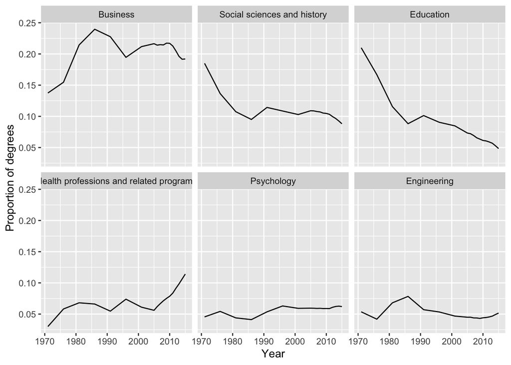

### Plot 2

*Hints:*

- Transparency is 0.5
- Color used is`"red"`

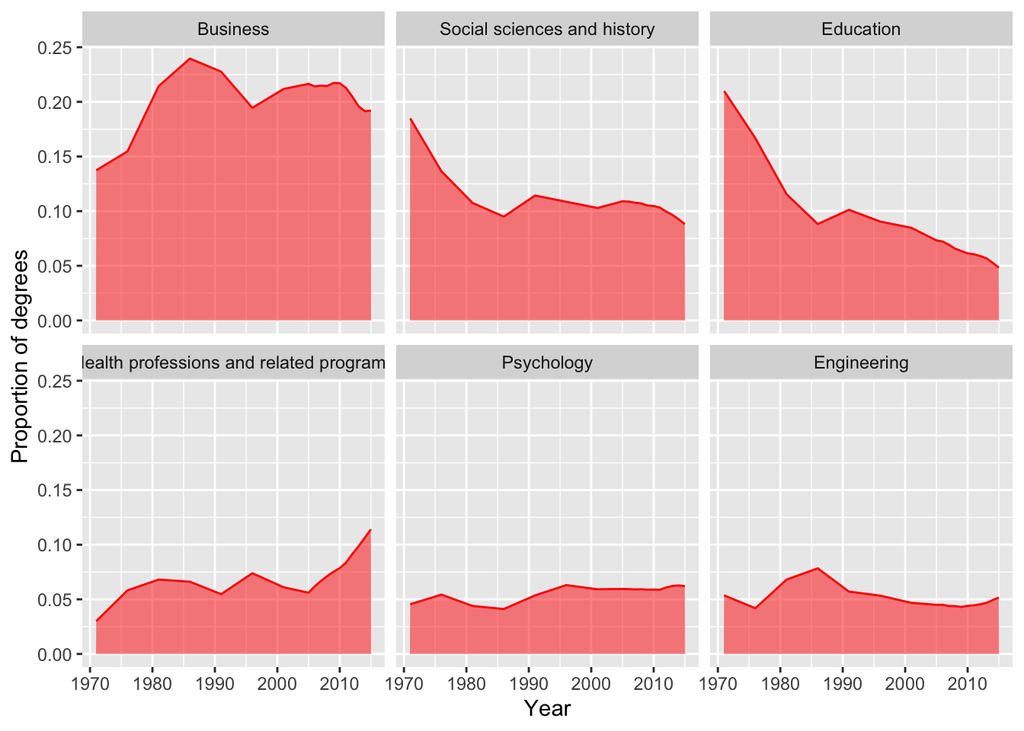

### Plot 3

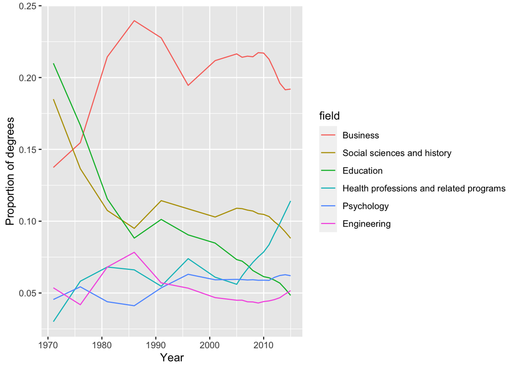

## Exercise 3

Using the `dow_jones_industrial` dataset, track the Dow Jones Industrial Average at close each day during 2009. Recreate the following graphics as precisely as possible.

### Plot 1

It will be easier to see the trend if we add a smooth fit line to the graph.

*Hints:*

- colors: “purple”, “red”, “green”
- Wiggliness for `loess` is 0.3

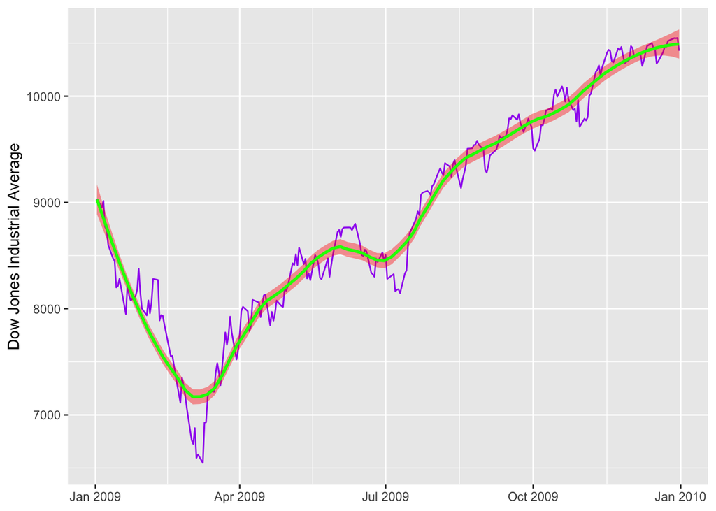

### Plot 2

There are many different smoothing methods in statistics. By default `geom_smooth()` uses `loess`.

Another extremely popular smoothing method in statistics is the use of splines. A spline function is a curve constructed from polynomial segments that are subject to conditions or continuity at their joints. Generally, a difficulty is you need to determine the number of `knots`, however this method is popular in predictive models.

Add a natural cubic spline smoother with `df = 6`.

*Hints:*

- need the `splines` package
- use method `"lm"`
- `y ~ ns(x, 6)`

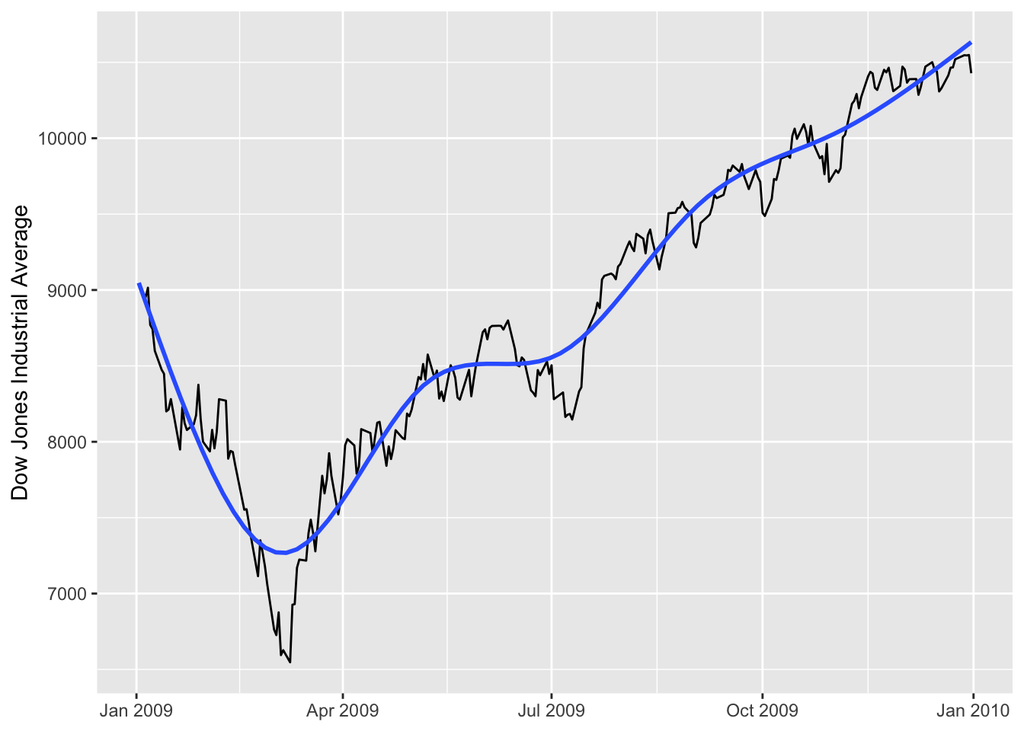

## Exercise 4

We’ll be using the BRFSS (Behavioral Risk Factor Surveillance System) survey collected annually by the Centers for Disease Control and Prevention (CDC). The data can be found in the provided `cdc.txt` file — place this file in your `/data` subdirectory. The dataset contains 20,000 complete observations/records of 9 variables/fields, described below.

- `genhlth` - How would you rate your general health? (excellent, very good, good, fair, poor)
- `exerany` - Have you exercised in the past month? (`1 = yes`, `0 = no`)
- `hlthplan` - Do you have some form of health coverage? (`1 = yes`, `0 = no`)
- `smoke100` - Have you smoked at least 100 cigarettes in your life time? (`1 = yes`, `0 = no`)
- `height` - height in inches
- `weight` - weight in pounds
- `wtdesire` - weight desired in pounds
- `age` - in years
- `gender` - `m` for males and `f` for females

Using the `cdc` dataset, we want to visualize the **distribution** between weight and gender based on general health. Recreate the Plot 1 and Plot 2 which represent 2 attempts at this.

### Plot 1

*Hints:*

- Transparency is 0.2
- Horizontal axis should have lower limit of 50 and upper limit of 400

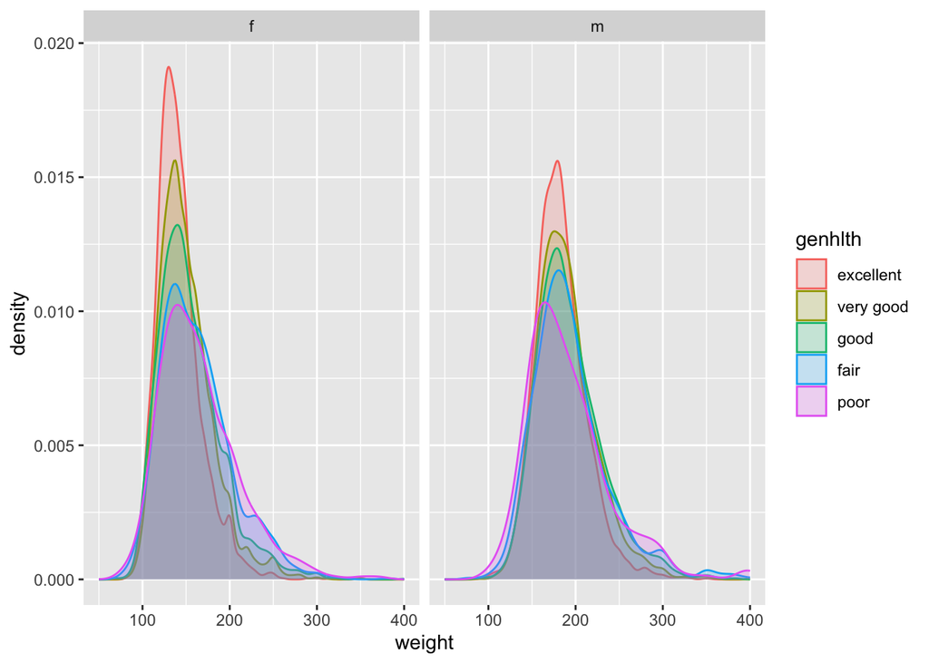

### Plot 2

*Hints:*

- Transparency is 0.4

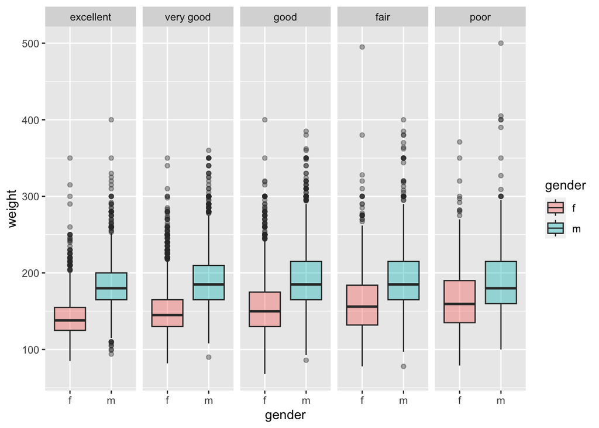

### Plot 3

Choose one more way to visualize the **distribution** of weight based on gender and general health.

*Requirements:*

- The geom layer cannot be `geom_boxplot()` or `geom_density()`
- Appropriately label the x- and y- axis
- Add a title

### Question 4.1

Compare and contrast the different ways to visualize a distribution. In other words, when might you use a histogram vs density vs boxplot? Which did you find the most useful in interpreting the plots above?

## Exercise 5

Using the `cdc` dataset, construct this plot in **two** ways. Once using `geom_bar()` and once using the `geom_col()`. May need to do some data wrangling for one of these.

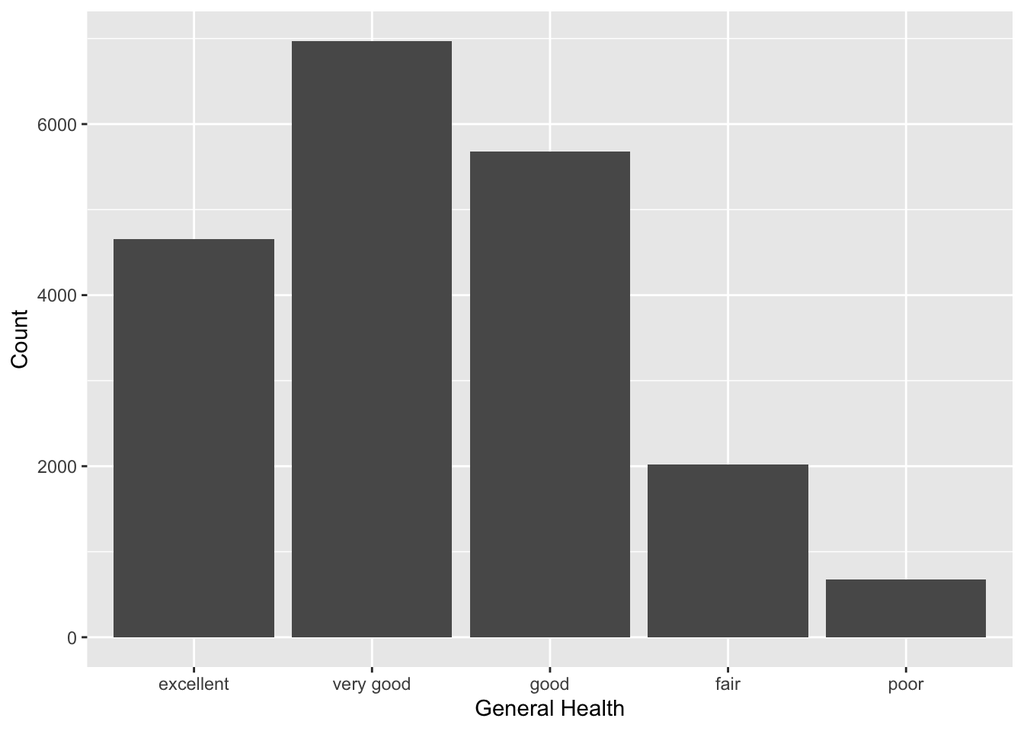